# Análise de Profissionais na Área de Dados no Brasil (2024–2025)

**Disciplina:** Análise de Dados IV

**Professor:** José Eduardo

**Integrantes do Grupo:**

- Alexandre Marcelo Marques Filho
- João Victor Tozoni
- Pedro Humberto Bitencourt Nascimento

## Introdução e Objetivos do Relatório

**Produto da Etapa:** Este relatório técnico (exportado em formato HTML), contendo os códigos em Python, as visualizações gráficas geradas e as análises interpretativas dos resultados encontrados.

## Fonte dos Dados

Os dados utilizados foram extraídos da 5ª edição da pesquisa **"State of Data Brazil"**, conduzida pela Data Hackers em parceria com a Bain & Company. A coleta ocorreu entre **14 de outubro e 18 de dezembro de 2024**, com a participação de **5.217 profissionais** brasileiros da área de dados.

```python
# Bibliotecas principais para análise de dados
import pandas as pd
import numpy as np

# Visualização de dados (gráficos estáticos e interativos)
import matplotlib.pyplot as plt
import seaborn as sns
import plotly.express as px
import plotly.io as pio

# Configurações para melhor visualização dos gráficos
plt.style.use('seaborn-v0_8-darkgrid')
sns.set_palette('Set2')

# Adicione esta linha para garantir que os gráficos apareçam
pio.renderers.default = "kaggle"

# Carregando o dataset
file_path = '/kaggle/input/state-of-data-brazil-20242025/Final Dataset - State of Data 2024 - Kaggle - df_survey_2024.csv'
df = pd.read_csv(file_path)

# Exibindo dimensões da base
print(f"Número de linhas: {df.shape[0]}")
print(f"Número de colunas: {df.shape[1]}")

#Suprimir warnings
import warnings
warnings.filterwarnings('ignore')

# Visualizando os primeiros registros
df.head(10)
```

```
Número de linhas: 5217
Número de colunas: 403
```

|  | 0.a_token | 0.d_data/hora_envio | 1.a_idade | 1.a.1_faixa_idade | 1.b_genero | 1.c_cor/raca/etnia | 1.d_pcd | 1.e_experiencia_profissional_prejudicada | 1.e.1_Não acredito que minha experiência profissional seja afetada | 1.e.2_Sim, devido a minha Cor/Raça/Etnia | ... | 8.d.3_Entrando em contato com os times de negócio para definição do problema, identificar a solução e apresentação de resultados. | 8.d.4_Desenvolvendo modelos de Machine Learning com o objetivo de colocar em produção em sistemas (produtos de dados). | 8.d.5_Colocando modelos em produção, criando os pipelines de dados, APIs de consumo e monitoramento. | 8.d.6_Cuidando da manutenção de modelos de Machine Learning já em produção, atuando no monitoramento, ajustes e refatoração quando necessário. | 8.d.7_Realizando construções de dashboards em ferramentas de BI como PowerBI, Tableau, Looker, Qlik, etc. | 8.d.8_Utilizando ferramentas avançadas de estatística como SAS, SPSS, Stata etc, para realizar análises. | 8.d.9_Criando e dando manutenção em ETLs, DAGs e automações de pipelines de dados. | 8.d.10_Criando e gerenciando soluções de Feature Store e cultura de MLOps. | 8.d.11_Criando e mantendo a infra que meus modelos e soluções rodam (clusters, servidores, API, containers, etc.) | 8.d.12_Treinando e aplicando LLM's para solucionar problemas de negócio. |
| --- | --- | --- | --- | --- | --- | --- | --- | --- | --- | --- | --- | --- | --- | --- | --- | --- | --- | --- | --- | --- | --- |
| 0 | reb94rv0msth7q4nreb94riaq80iz3yi | 16/10/2024 11:19:17 | 18 | 17-21 | Masculino | Branca | Não | NaN | NaN | NaN | ... | NaN | NaN | NaN | NaN | NaN | NaN | NaN | NaN | NaN | NaN |
| 1 | 1zc66g69jjt49y32l1zc66g8wqj79m4e | 16/10/2024 20:45:31 | 18 | 17-21 | Masculino | Branca | Não | NaN | NaN | NaN | ... | NaN | NaN | NaN | NaN | NaN | NaN | NaN | NaN | NaN | NaN |
| 2 | uu99wmam4n5kc2uu99wmydf0rk7l58f7 | 17/10/2024 18:10:59 | 18 | 17-21 | Masculino | Parda | Não | Não acredito que minha experiência profissiona... | 1.0 | 0.0 | ... | NaN | NaN | NaN | NaN | NaN | NaN | NaN | NaN | NaN | NaN |
| 3 | 3ynsw7z0hl5hhpbfvaeqk73ynsw7z04l | 22/10/2024 18:03:00 | 18 | 17-21 | Masculino | Branca | Não | NaN | NaN | NaN | ... | NaN | NaN | NaN | NaN | NaN | NaN | NaN | NaN | NaN | NaN |
| 4 | v6bji2ct5xckpl1uouv6bjiotkrf3b4f | 23/10/2024 01:33:23 | 18 | 17-21 | Masculino | Branca | Não | NaN | NaN | NaN | ... | NaN | NaN | NaN | NaN | NaN | NaN | NaN | NaN | NaN | NaN |
| 5 | jct4toasj61rygexnyug3zjct4toascu | 25/10/2024 12:02:06 | 18 | 17-21 | Masculino | Parda | Não | Não acredito que minha experiência profissiona... | 1.0 | 0.0 | ... | NaN | NaN | NaN | NaN | NaN | NaN | NaN | NaN | NaN | NaN |
| 6 | vcvc4otfqznwludyp3mvcvc8euvs299t | 12/11/2024 19:45:44 | 18 | 17-21 | Masculino | Parda | Sim | Não acredito que minha experiência profissiona... | 1.0 | 0.0 | ... | NaN | NaN | NaN | NaN | NaN | NaN | NaN | NaN | NaN | NaN |
| 7 | 7o0jgas7pedzh1dr17o0jgzt0irkbqo6 | 21/11/2024 05:13:09 | 18 | 17-21 | Masculino | Parda | Não | Não acredito que minha experiência profissiona... | 1.0 | 0.0 | ... | NaN | NaN | NaN | NaN | NaN | NaN | NaN | NaN | NaN | NaN |
| 8 | gmkbjmsg8fzfqljgmkbjmkr5zfkex28o | 09/12/2024 12:16:43 | 18 | 17-21 | Masculino | Parda | Não | Não acredito que minha experiência profissiona... | 1.0 | 0.0 | ... | NaN | NaN | NaN | NaN | NaN | NaN | NaN | NaN | NaN | NaN |
| 9 | vwsjeyi7044yittt3zdwvwsjefc53s6y | 09/12/2024 14:03:12 | 18 | 17-21 | Masculino | Parda | Não | Não acredito que minha experiência profissiona... | 1.0 | 0.0 | ... | NaN | NaN | NaN | NaN | NaN | NaN | NaN | NaN | NaN | NaN |

10 rows × 403 columns

## Célula: Exploração inicial das colunas da base

Aqui vamos listar os nomes das colunas para identificar quais estão ligadas a:

- **Formação acadêmica** (graduação, pós, etc.);
- **Cargo ou função**;
- **Salário**;
- **Região geográfica** (ou local de trabalho).

```python
# Exibir todas as colunas disponíveis no DataFrame
pd.set_option('display.max_columns', None)  # permite visualizar todas as colunas
df.columns.to_list()
```

```
['0.a_token',
 '0.d_data/hora_envio',
 '1.a_idade',
 '1.a.1_faixa_idade',
 '1.b_genero',
 '1.c_cor/raca/etnia',
 '1.d_pcd',
 '1.e_experiencia_profissional_prejudicada',
 '1.e.1_Não acredito que minha experiência profissional seja afetada',
 '1.e.2_Sim, devido a minha Cor/Raça/Etnia',
 '1.e.3_Sim, devido a minha identidade de gênero',
 '1.e.4_Sim, devido ao fato de ser PCD',
 '1.i.1_uf_onde_mora',
 '1.f.1_Quantidade de oportunidades de emprego/vagas recebidas',
 '1.f.2_Senioridade das vagas recebidas em relação à sua experiência',
 '1.f.3_Aprovação em processos seletivos/entrevistas',
 '1.f.4_Oportunidades de progressão de carreira',
 '1.f.5_Velocidade de progressão de carreira',
 '1.f.6_Nível de cobrança no trabalho/Stress no trabalho',
 '1.f.7_Atenção dada pelas pessoas diante das minhas opiniões e ideias',
 '1.f.8_Relação com outras pessoas da empresa, em momentos de trabalho',
 '1.f.9_Relação com outras pessoas da empresa, em momentos de integração e outros momentos fora do trabalho',
 '1.i.2_regiao_onde_mora',
 '1.f_aspectos_prejudicados',
 '1.k.1_uf_de_origem',
 '1.k.2_regiao_de_origem',
 '1.g_vive_no_brasil',
 '1.h_pais_onde_mora',
 '1.i_estado_onde_mora',
 '1.j_vive_no_estado_de_formacao',
 '1.k_estado_de_origem',
 '1.l_nivel_de_ensino',
 '1.m_área_de_formação',
 '2.a_situação_de_trabalho',
 '2.b_setor',
 '2.c_numero_de_funcionarios',
 '2.d_atua_como_gestor',
 '2.e_cargo_como_gestor',
 '2.f_cargo_atual',
 '2.g_nivel',
```

[output cut: 348 more lines]

```
 '8.c.10_Plataformas de Data Apps (Streamlit, Shiny, Plotly Dash etc).',
 '8.c.11_Ferramentas de estatística avançada como SPSS, SAS, etc.',
 '8.d_maior_tempo_gasto_como_ds',
 '8.d.1_Estudos Ad-hoc com o objetivo de confirmar hipóteses, realizar modelos preditivos, forecasts, análise de cluster para resolver problemas pontuais e responder perguntas das áreas de negócio.',
 '8.d.2_Coletando e limpando dos dados que uso para análise e modelagem.',
 '8.d.3_Entrando em contato com os times de negócio para definição do problema, identificar a solução e apresentação de resultados.',
 '8.d.4_Desenvolvendo modelos de Machine Learning com o objetivo de colocar em produção em sistemas (produtos de dados).',
 '8.d.5_Colocando modelos em produção, criando os pipelines de dados, APIs de consumo e monitoramento.',
 '8.d.6_Cuidando da manutenção de modelos de Machine Learning já em produção, atuando no monitoramento, ajustes e refatoração quando necessário.',
 '8.d.7_Realizando construções de dashboards em ferramentas de BI como PowerBI, Tableau, Looker, Qlik, etc.',
 '8.d.8_Utilizando ferramentas avançadas de estatística como SAS, SPSS, Stata etc, para realizar análises.',
 '8.d.9_Criando e dando manutenção em ETLs, DAGs e automações de pipelines de dados.',
 '8.d.10_Criando e gerenciando soluções de Feature Store e cultura de MLOps.',
 '8.d.11_Criando e mantendo a infra que meus modelos e soluções rodam (clusters, servidores, API, containers, etc.)',
 "8.d.12_Treinando e aplicando LLM's para solucionar problemas de negócio."]
```

## 🔍 Etapa 3: Seleção das Colunas Relevantes

Nesta etapa, vamos extrair do dataset original apenas as colunas que são essenciais para a nossa análise.

Criamos um novo DataFrame chamado `df_subset` contendo apenas essas colunas, que serão a base para os próximos passos da análise.

```python
# Lista com as colunas que serão utilizadas na análise
colunas_relevantes = [
    # Identificador único
    '0.a_token',

    # Dados demográficos
    '1.a_idade',
    '1.a.1_faixa_idade',
    '1.b_genero',
    '1.c_cor/raca/etnia',

    # Localização
    '1.i.1_uf_onde_mora',
    '1.i.2_regiao_onde_mora',

    # Formação acadêmica
    '1.l_nivel_de_ensino',        # Graduação, Pós etc.
    '1.m_área_de_formação',       # Exatas, Humanas, TI etc.

    # Situação de trabalho e empresa
    '2.a_situação_de_trabalho',
    '2.b_setor',
    '2.c_numero_de_funcionarios',

    # Cargo e experiência
    '2.f_cargo_atual',
    '2.g_nivel',
    '2.i_tempo_de_experiencia_em_dados',
    '2.j_tempo_de_experiencia_em_ti',

    # Faixa salarial
    '2.h_faixa_salarial',

    # Satisfação e planos de mudança
    '2.k_satisfeito_atualmente',
    '2.n_planos_de_mudar_de_emprego_6m',

    # Outras colunas úteis para interpretação
    '2.l_motivo_insatisfacao',   # Pode ajudar a entender fatores além da formação
    '2.o_criterios_para_escolha_de_emprego'  # Mostra o que valorizam
]


# Criar um novo DataFrame apenas com as colunas relevantes
df_subset = df[colunas_relevantes].copy()

#Definir como índice no seu DataFrame
df.set_index('0.a_token', inplace=True)


# Visualizar as 5 primeiras linhas para conferir se os dados foram corretamente extraídos
df_subset.head()
```

|  | 0.a_token | 1.a_idade | 1.a.1_faixa_idade | 1.b_genero | 1.c_cor/raca/etnia | 1.i.1_uf_onde_mora | 1.i.2_regiao_onde_mora | 1.l_nivel_de_ensino | 1.m_área_de_formação | 2.a_situação_de_trabalho | 2.b_setor | 2.c_numero_de_funcionarios | 2.f_cargo_atual | 2.g_nivel | 2.i_tempo_de_experiencia_em_dados | 2.j_tempo_de_experiencia_em_ti | 2.h_faixa_salarial | 2.k_satisfeito_atualmente | 2.n_planos_de_mudar_de_emprego_6m | 2.l_motivo_insatisfacao | 2.o_criterios_para_escolha_de_emprego |
| --- | --- | --- | --- | --- | --- | --- | --- | --- | --- | --- | --- | --- | --- | --- | --- | --- | --- | --- | --- | --- | --- |
| 0 | reb94rv0msth7q4nreb94riaq80iz3yi | 18 | 17-21 | Masculino | Branca | RS | Sul | Estudante de Graduação | Computação / Engenharia de Software / Sistemas... | Estagiário | Marketing | de 101 a 500 | Analista de Dados/Data Analyst | Júnior | de 1 a 2 anos | de 1 a 2 anos | de R$ 1.001/mês a R$ 2.000/mês | True | Não estou buscando, mas me considero aberto a ... | NaN | Remuneração/Salário, Reputação que a empresa t... |
| 1 | 1zc66g69jjt49y32l1zc66g8wqj79m4e | 18 | 17-21 | Masculino | Branca | SC | Sul | Estudante de Graduação | Computação / Engenharia de Software / Sistemas... | Estagiário | Finanças ou Bancos | Acima de 3.000 | Analista de BI/BI Analyst | Júnior | Menos de 1 ano | Menos de 1 ano | Menos de R$ 1.000/mês | True | Não estou buscando e não pretendo mudar de emp... | NaN | Oportunidade de aprendizado e trabalhar com re... |
| 2 | uu99wmam4n5kc2uu99wmydf0rk7l58f7 | 18 | 17-21 | Masculino | Parda | SP | Sudeste | Estudante de Graduação | Computação / Engenharia de Software / Sistemas... | Empregado (CLT) | Indústria | de 501 a 1.000 | Outra Opção | Júnior | Não tenho experiência na área de dados | Não tive experiência na área de TI/Engenharia ... | de R$ 1.001/mês a R$ 2.000/mês | False | Estou em busca de oportunidades dentro ou fora... | Remuneração/Salário não corresponde a realidad... | Remuneração/Salário, Propósito do trabalho e d... |
| 3 | 3ynsw7z0hl5hhpbfvaeqk73ynsw7z04l | 18 | 17-21 | Masculino | Branca | SP | Sudeste | Estudante de Graduação | Computação / Engenharia de Software / Sistemas... | Estagiário | Tecnologia/Fábrica de Software | de 501 a 1.000 | Analista de Dados/Data Analyst | Júnior | Menos de 1 ano | Não tive experiência na área de TI/Engenharia ... | de R$ 1.001/mês a R$ 2.000/mês | True | Não estou buscando e não pretendo mudar de emp... | NaN | Oportunidade de aprendizado e trabalhar com re... |
| 4 | v6bji2ct5xckpl1uouv6bjiotkrf3b4f | 18 | 17-21 | Masculino | Branca | SP | Sudeste | Estudante de Graduação | Computação / Engenharia de Software / Sistemas... | Estagiário | Tecnologia/Fábrica de Software | de 1.001 a 3.000 | Desenvolvedor/ Engenheiro de Software/ Analist... | Júnior | Menos de 1 ano | Menos de 1 ano | de R$ 1.001/mês a R$ 2.000/mês | True | Não estou buscando e não pretendo mudar de emp... | NaN | Oportunidade de aprendizado e trabalhar com re... |

## 🧹 Etapa 4: Tratamento de Valores Ausentes e Inconsistentes

Nesta etapa, faremos a verificação de valores ausentes e registros com dados inconsistentes nas colunas selecionadas. Esse processo é fundamental para garantir a integridade das análises e visualizações que serão construídas nas próximas etapas.

### 🔍 O que será feito:

- Verificar quantos valores nulos existem em cada coluna.
- Remover ou substituir valores ausentes conforme o caso.
- Identificar e corrigir **formatações inconsistentes** em colunas como faixa salarial ou formação acadêmica.

```python
# Verificar quantidade de valores ausentes em cada coluna
df_subset.isnull().sum()
```

```
0.a_token                                   0
1.a_idade                                   0
1.a.1_faixa_idade                           0
1.b_genero                                  0
1.c_cor/raca/etnia                          0
1.i.1_uf_onde_mora                        142
1.i.2_regiao_onde_mora                    142
1.l_nivel_de_ensino                         0
1.m_área_de_formação                       94
2.a_situação_de_trabalho                    0
2.b_setor                                 354
2.c_numero_de_funcionarios                354
2.f_cargo_atual                          1399
2.g_nivel                                1399
2.i_tempo_de_experiencia_em_dados         354
2.j_tempo_de_experiencia_em_ti            354
2.h_faixa_salarial                        354
2.k_satisfeito_atualmente                 354
2.n_planos_de_mudar_de_emprego_6m         354
2.l_motivo_insatisfacao                  3690
2.o_criterios_para_escolha_de_emprego     355
dtype: int64
```

## 🧹 Etapa 4: Tratamento de Valores Ausentes

Para garantir a qualidade das análises, removemos registros com valores ausentes.

Essas colunas são essenciais para cruzamentos como: formação vs salário, cargo vs região, etc.

```python
import re

# Exibir valores ausentes inicialmente
print("Valores ausentes por coluna:")
print(df_subset.isnull().sum())

# 1. Preencher colunas categóricas com "Não informado"
colunas_categoricas = [
    '1.i.1_uf_onde_mora',
    '1.i.2_regiao_onde_mora',
    '1.m_área_de_formação',
    '2.b_setor',
    '2.k_satisfeito_atualmente',
    '2.n_planos_de_mudar_de_emprego_6m',
    '2.l_motivo_insatisfacao',
    '2.o_criterios_para_escolha_de_emprego'
]

for col in colunas_categoricas:
    df_subset[col] = df_subset[col].fillna('Não informado')

# 2. Preencher com "Não aplicável" os que não trabalham
cond_nao_trabalha = df_subset['2.a_situação_de_trabalho'].isin([
    'Desempregado', 'Estudante', 'Buscando recolocação'
])

for col in ['2.f_cargo_atual', '2.g_nivel', '2.h_faixa_salarial']:
    df_subset.loc[cond_nao_trabalha, col] = df_subset.loc[cond_nao_trabalha, col].fillna('Não aplicável')
    df_subset[col] = df_subset[col].fillna('Não informado')

# 3. Função para extrair valor médio das faixas
def extrair_media_faixa(valor):
    if pd.isna(valor) or valor in ['Não informado', 'Não aplicável']:
        return np.nan

    valor = str(valor).lower().replace('.', '').replace('r$', '').replace('/mês', '').strip()

    # Faixa tipo "de X a Y"
    match_de_a = re.match(r'de\s*(\d+)\s*a\s*(\d+)', valor)
    if match_de_a:
        x = int(match_de_a.group(1))
        y = int(match_de_a.group(2))
        return (x + y) / 2

    # Faixa tipo "Até X"
    match_ate = re.match(r'at[eé]\s*(\d+)', valor)
    if match_ate:
        return int(match_ate.group(1))

    # Faixa tipo "Acima de X"
    match_acima = re.match(r'acima de\s*(\d+)', valor)
    if match_acima:
        return int(match_acima.group(1)) + 1000  # estimativa

    # Faixa tipo "Menos de X"
    match_menos = re.match(r'menos de\s*(\d+)', valor)
    if match_menos:
        return int(match_menos.group(1)) / 2  # melhor estimativa que -500

    # Sem experiência
    if "não tenho experiência" in valor or "não tive experiência" in valor:
        return 0

    # Mais de 10 anos → usar 11 como conservador
    if "mais de 10 anos" in valor:
        return 11

    return np.nan

# 4. Converter faixas para colunas numéricas
colunas_faixas = [
    '2.c_numero_de_funcionarios',
    '2.i_tempo_de_experiencia_em_dados',
    '2.j_tempo_de_experiencia_em_ti',
    '2.h_faixa_salarial'
]

for col in colunas_faixas:
    nova_coluna = col + '_num'
    df_subset[nova_coluna] = df_subset[col].apply(extrair_media_faixa)

# 5. Visualizar algumas transformações feitas
print("\nVerificação das faixas convertidas:")
for col in colunas_faixas:
    print(f"\nColuna: {col} → {col}_num")
    print(df_subset[[col, col + '_num']].drop_duplicates().sort_values(by=col + '_num'))

# 6. Mostrar valores ausentes após tratamento
print("\nValores ausentes finais (após tratamento):")
print(df_subset.isnull().sum())
```

```
Valores ausentes por coluna:
0.a_token                                   0
1.a_idade                                   0
1.a.1_faixa_idade                           0
1.b_genero                                  0
1.c_cor/raca/etnia                          0
1.i.1_uf_onde_mora                        142
1.i.2_regiao_onde_mora                    142
1.l_nivel_de_ensino                         0
1.m_área_de_formação                       94
2.a_situação_de_trabalho                    0
2.b_setor                                 354
2.c_numero_de_funcionarios                354
2.f_cargo_atual                          1399
2.g_nivel                                1399
2.i_tempo_de_experiencia_em_dados         354
2.j_tempo_de_experiencia_em_ti            354
2.h_faixa_salarial                        354
2.k_satisfeito_atualmente                 354
2.n_planos_de_mudar_de_emprego_6m         354
2.l_motivo_insatisfacao                  3690
2.o_criterios_para_escolha_de_emprego     355
dtype: int64

Verificação das faixas convertidas:

Coluna: 2.c_numero_de_funcionarios → 2.c_numero_de_funcionarios_num
   2.c_numero_de_funcionarios  2.c_numero_de_funcionarios_num
17                   de 1 a 5                             3.0
6                   de 6 a 10                             8.0
9                  de 11 a 50                            30.5
23                de 51 a 100                            75.5
0                de 101 a 500                           300.5
2              de 501 a 1.000                           750.5
4            de 1.001 a 3.000                          2000.5
1              Acima de 3.000                          4000.0
5                         NaN                             NaN

Coluna: 2.i_tempo_de_experiencia_em_dados → 2.i_tempo_de_experiencia_em_dados_num
           2.i_tempo_de_experiencia_em_dados  \
```

[output cut: 69 more lines]

```
2.c_numero_de_funcionarios               354
2.f_cargo_atual                            0
2.g_nivel                                  0
2.i_tempo_de_experiencia_em_dados        354
2.j_tempo_de_experiencia_em_ti           354
2.h_faixa_salarial                         0
2.k_satisfeito_atualmente                  0
2.n_planos_de_mudar_de_emprego_6m          0
2.l_motivo_insatisfacao                    0
2.o_criterios_para_escolha_de_emprego      0
2.c_numero_de_funcionarios_num           354
2.i_tempo_de_experiencia_em_dados_num    354
2.j_tempo_de_experiencia_em_ti_num       354
2.h_faixa_salarial_num                   354
dtype: int64
```

```python
# 1. Preencher valores ausentes com a mediana (exceto salário)
colunas_com_mediana = [
    '2.c_numero_de_funcionarios_num',
    '2.i_tempo_de_experiencia_em_dados_num',
    '2.j_tempo_de_experiencia_em_ti_num',
]

for col in colunas_com_mediana:
    mediana = df_subset[col].median()
    df_subset[col].fillna(mediana, inplace=True)

# 2. Remover linhas onde a faixa salarial não foi informada
df_subset = df_subset[df_subset['2.h_faixa_salarial_num'].notna()]

# 3. Verificação final dos dados ausentes
print("\nValores ausentes finais (100% prontos para análise):")
print(df_subset.isnull().sum())
```

```
Valores ausentes finais (100% prontos para análise):
0.a_token                                0
1.a_idade                                0
1.a.1_faixa_idade                        0
1.b_genero                               0
1.c_cor/raca/etnia                       0
1.i.1_uf_onde_mora                       0
1.i.2_regiao_onde_mora                   0
1.l_nivel_de_ensino                      0
1.m_área_de_formação                     0
2.a_situação_de_trabalho                 0
2.b_setor                                0
2.c_numero_de_funcionarios               0
2.f_cargo_atual                          0
2.g_nivel                                0
2.i_tempo_de_experiencia_em_dados        0
2.j_tempo_de_experiencia_em_ti           0
2.h_faixa_salarial                       0
2.k_satisfeito_atualmente                0
2.n_planos_de_mudar_de_emprego_6m        0
2.l_motivo_insatisfacao                  0
2.o_criterios_para_escolha_de_emprego    0
2.c_numero_de_funcionarios_num           0
2.i_tempo_de_experiencia_em_dados_num    0
2.j_tempo_de_experiencia_em_ti_num       0
2.h_faixa_salarial_num                   0
dtype: int64
```

# Distribuição de Profissionais de Dados no Brasil

Este gráfico apresenta a distribuição dos profissionais da área de dados no Brasil, segmentada por Unidade Federativa (UF) e por Região. O objetivo é destacar a concentração de talentos em diferentes localidades, identificando quais estados e regiões possuem o maior número de profissionais atuando no setor. A amostra contempla diversos cargos, incluindo Analistas, Cientistas e Engenheiros de Dados, abrangendo diferentes níveis de experiência, desde júnior até gestores seniores.

## Análise dos Resultados

A distribuição dos profissionais de dados mostra uma clara concentração nas regiões Sudeste e Sul do país, que juntos reúnem a grande maioria dos respondentes. O Sudeste, com 2.940 profissionais, destaca-se como o principal polo, refletindo o maior desenvolvimento econômico e tecnológico da região, além da concentração de grandes centros urbanos e empresas de tecnologia.

A região Sul, com 989 profissionais, também apresenta uma participação significativa, seguida pelo Nordeste, com 447 profissionais. O Centro-Oeste e o Norte, com 300 e 57 profissionais respectivamente, têm uma representatividade menor, o que pode estar associado a menor densidade populacional e menos hubs tecnológicos nessas regiões.

Além disso, é importante destacar que 130 profissionais não informaram sua localização, o que pode indicar desafios na coleta ou na disposição para compartilhar esses dados.

## Considerações

Devido às práticas de anonimização dos dados, alguns estados com menor número de respondentes podem ter sua identificação restrita à região correspondente.

Essa análise oferece insights importantes para empresas que buscam compreender a distribuição da força de trabalho em dados no país, para profissionais interessados em tendências regionais, e para formuladores de políticas públicas que visam o desenvolvimento equilibrado do setor em âmbito regional.

Promover o crescimento das áreas de tecnologia e dados nas regiões menos representadas pode contribuir para o desenvolvimento socioeconômico mais equilibrado no Brasil, abrindo novas oportunidades e reduzindo desigualdades regionais.

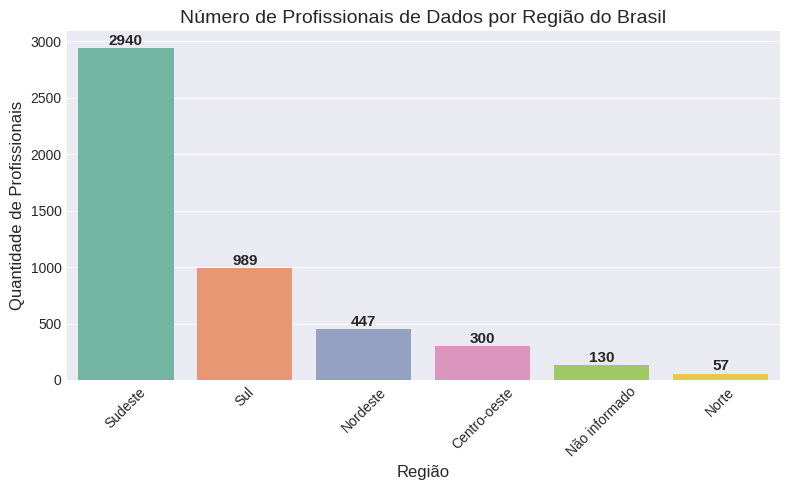

```python
# Contagem de profissionais por região
regiao_counts = df_subset['1.i.2_regiao_onde_mora'].value_counts().reset_index()
regiao_counts.columns = ['Região', 'Quantidade']

plt.figure(figsize=(8,5))
sns.barplot(data=regiao_counts, x='Região', y='Quantidade', palette='Set2')

# Adiciona os valores como rótulos em cima das barras
for i, row in regiao_counts.iterrows():
    plt.text(i, row['Quantidade'] + max(regiao_counts['Quantidade']) * 0.01,  # Pequeno espaçamento acima da barra
             int(row['Quantidade']),
             ha='center',
             fontsize=11,
             fontweight='bold')

plt.title('Número de Profissionais de Dados por Região do Brasil', fontsize=14)
plt.xlabel('Região', fontsize=12)
plt.ylabel('Quantidade de Profissionais', fontsize=12)
plt.xticks(rotation=45)
plt.tight_layout()
plt.show()
```

# Análise da Faixa Etária dos Profissionais de Dados no Brasil

## Distribuição da Idade

A distribuição da idade dos profissionais de dados apresenta uma concentração significativa entre as faixas dos 25 aos 35 anos, com pico próximo aos 28 anos. Essa faixa etária representa o grupo majoritário da amostra, indicando uma predominância de profissionais jovens na área.

O histograma revela que a quantidade de profissionais começa a cair gradativamente após os 35 anos, e há uma presença menor de profissionais acima dos 50 anos, indicando uma possível renovação constante na área ou maior atração de jovens talentos.

## Estatísticas Resumo da Idade

- **Média**: 32,3 anos
- **Mediana**: 31,0 anos
- **Idade Mínima**: 18 anos
- **Idade Máxima**: 68 anos

A média e a mediana próximas indicam uma distribuição relativamente simétrica, com leve concentração para a faixa jovem-adulta. A presença de outliers acima de 50 anos pode ser observada no boxplot, evidenciando profissionais mais experientes, embora em número reduzido.

## Interpretação e Implicações

Essa predominância de jovens profissionais sugere que o setor de dados está em expansão, atraindo novos talentos, provavelmente devido à crescente demanda do mercado por habilidades em dados. A idade média próxima dos 30 anos sugere um perfil profissional em início ou meio de carreira, com potencial para crescimento e desenvolvimento contínuo.

Além disso, a presença de profissionais mais experientes, ainda que em menor número, é importante para equilibrar o mercado, trazendo conhecimento e maturidade para as equipes.

```
Estatísticas da Idade:
Média: 32.3
Mediana: 31.0
Mínima: 18
Máxima: 68
```

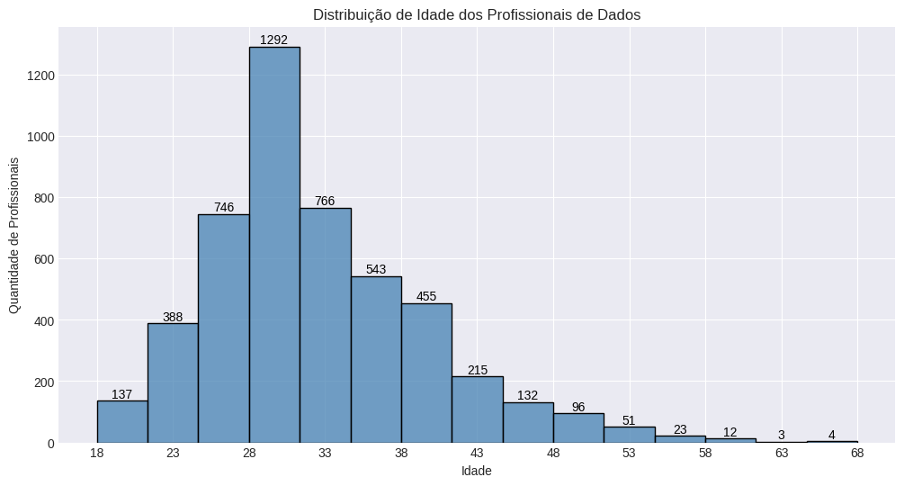

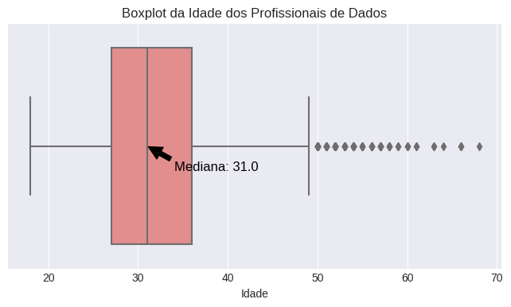

```python
# Considerando que a coluna de idade é '1.a_idade' e já está limpa e numérica
idades = df_subset['1.a_idade'].dropna()

# Estatísticas básicas
media_idade = idades.mean()
mediana_idade = idades.median()
min_idade = idades.min()
max_idade = idades.max()

print(f"Estatísticas da Idade:\nMédia: {media_idade:.1f}\nMediana: {mediana_idade}\nMínima: {min_idade}\nMáxima: {max_idade}")

# Plot: Histograma com valores nas barras
plt.figure(figsize=(12, 6))
ax = sns.histplot(idades, bins=15, kde=False, color='steelblue')

# Adicionar rótulos com o valor da contagem em cada barra
for p in ax.patches:
    height = p.get_height()
    if height > 0:
        ax.annotate(f'{int(height)}', (p.get_x() + p.get_width()/2, height),
                    ha='center', va='bottom', fontsize=10, color='black')

plt.title('Distribuição de Idade dos Profissionais de Dados')
plt.xlabel('Idade')
plt.ylabel('Quantidade de Profissionais')
plt.xticks(range(int(min_idade), int(max_idade)+1, 5))
plt.show()

# Plot: Boxplot da idade com valor da mediana destacado
plt.figure(figsize=(8, 4))
ax2 = sns.boxplot(x=idades, color='lightcoral')

# Adicionar anotação da mediana
ax2.annotate(f'Mediana: {mediana_idade}', xy=(mediana_idade, 0), xytext=(mediana_idade+3, 0.1),
             arrowprops=dict(facecolor='black', shrink=0.05),
             fontsize=12, color='black')

plt.title('Boxplot da Idade dos Profissionais de Dados')
plt.xlabel('Idade')
plt.yticks([])  # Remove eixo y pois não é relevante
plt.show()
```

## Análise de Gênero na Área de Dados

### Distribuição de Gênero na Amostra

A pesquisa revela uma **disparidade de gênero** na área de dados no Brasil. O setor é **predominantemente masculino**, com **76,1%** dos participantes se identificando com este gênero.

Em contrapartida, as mulheres representam apenas **23,5%** da amostra, indicando uma clara sub-representação. Uma pequena parcela de **0,4%** preferiu não informar ou se identificou como "Outro".

### Interpretação e Implicações

Esse cenário reflete um desafio histórico e estrutural de diversidade nas áreas de **tecnologia e STEM** (Ciência, Tecnologia, Engenharia e Matemática).

A lacuna de gênero na área de dados não apenas cria uma barreira para a participação de mulheres no setor, mas também representa uma perda de potencial inovador, já que equipes diversas tendem a ser mais criativas e a oferecer soluções mais abrangentes.

A baixa representatividade feminina destaca a **necessidade urgente** de políticas de inclusão mais eficazes. Promover um ambiente de trabalho equitativo, com oportunidades iguais de crescimento, é fundamental para atrair e reter talentos femininos, tornando o mercado de dados brasileiro mais justo e competitivo.

```python
# Contagem de valores para a coluna de gênero
genero_counts = df_subset['1.b_genero'].value_counts().reset_index()
genero_counts.columns = ['Gênero', 'Quantidade']

# Cálculo do percentual
total = genero_counts['Quantidade'].sum()
genero_counts['Percentual'] = (genero_counts['Quantidade'] / total) * 100

# Exibindo a tabela com os resultados
print("Distribuição de Gênero na Amostra:")
print(genero_counts.to_string(index=False))

# Criando o gráfico de pizza interativo com Plotly
fig = px.pie(
    genero_counts,
    names='Gênero',
    values='Quantidade',
    title='Proporção de Gênero entre Profissionais de Dados no Brasil',
    hole=0.3,  # Cria o efeito "donut chart"
    color_discrete_sequence=px.colors.qualitative.Set2 # Paleta de cores
)

# Melhorando a aparência do gráfico
fig.update_traces(
    textinfo='percent+label',
    pull=[0.05 if i == 0 else 0 for i in range(len(genero_counts))], # Destaca a maior fatia
    hovertemplate="<b>Gênero:</b> %{label}<br><b>Quantidade:</b> %{value}<br><b>Percentual:</b> %{percent}"
)

fig.update_layout(
    title_font_size=20,
    legend_title_text='Gênero',
    uniformtext_minsize=12,
    uniformtext_mode='hide'
)

fig.show()
```

```
Distribuição de Gênero na Amostra:
              Gênero  Quantidade  Percentual
           Masculino        3700   76.084721
            Feminino        1142   23.483446
Prefiro não informar          15    0.308452
               Outro           6    0.123381
```

[interactive chart not shown]

## Análise Étnico-Racial na Área de Dados

### Distribuição Étnico-Racial na Amostra

A pesquisa de autodeclaração de cor ou raça mostra que o setor de dados no Brasil não reflete a diversidade demográfica do país. Há uma **predominância de profissionais que se autodeclaram brancos**, correspondendo a **67,5%** do total.

Pessoas **pardas** representam **21,9%** e pessoas **pretas** compõem **6,4%** dos respondentes. Juntos, esses dois grupos, que formam a população negra, somam **28,3%** da amostra. Pessoas amarelas (**3,1%**) e indígenas (**0,2%**) têm uma representação minoritária.

### Interpretação e Implicações

Essa disparidade fica ainda mais evidente quando comparada aos dados do Censo de 2022 do IBGE, onde pessoas pardas (**45,3%**) e pretas (**10,2%**) formam juntas a maioria da população brasileira.

A **super-representação de pessoas brancas** e a **sub-representação de pessoas negras e indígenas** na área de dados indicam barreiras estruturais de acesso e oportunidade. Esse cenário mostra que o campo da tecnologia ainda é um espaço de baixa diversidade racial.

A falta de representatividade limita a pluralidade de ideias e pode perpetuar vieses em produtos e algoritmos. Para construir um ecossistema de dados mais justo e inovador, é crucial que as empresas promovam ativamente **políticas de equidade racial**. O objetivo é garantir que o setor reflita a real composição da sociedade brasileira.

```
Distribuição Étnico-Racial na Amostra:
               Etnia  Quantidade  Percentual
              Branca        3284   67.530331
               Parda        1067   21.941189
               Preta         309    6.354102
             Amarela         152    3.125643
Prefiro não informar          36    0.740284
            Indígena          10    0.205634
               Outra           5    0.102817
```

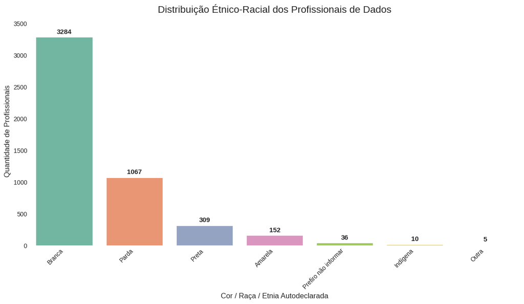

```python
# --- Análise Étnico-Racial com Seaborn e Matplotlib ---

# Contagem de valores para a coluna de cor/raça
raca_counts = df_subset['1.c_cor/raca/etnia'].value_counts().reset_index()
raca_counts.columns = ['Etnia', 'Quantidade']

# Cálculo do percentual para a tabela (não será usado no gráfico diretamente)
total_raca = raca_counts['Quantidade'].sum()
raca_counts['Percentual'] = (raca_counts['Quantidade'] / total_raca) * 100

# Exibindo a tabela com os resultados
print("Distribuição Étnico-Racial na Amostra:")
print(raca_counts.to_string(index=False))

# Plot: Gráfico de Barras Verticais com Seaborn
plt.figure(figsize=(12, 7))
ax = sns.barplot(
    data=raca_counts,
    x='Etnia',
    y='Quantidade',
    palette='Set2'
)

# Adicionar os valores no topo das barras
for p in ax.patches:
    height = p.get_height()
    ax.annotate(f'{int(height)}',
                (p.get_x() + p.get_width() / 2., height),
                ha='center', va='center',
                xytext=(0, 9),
                textcoords='offset points',
                fontsize=11,
                fontweight='bold')

# Configurações do gráfico
plt.title('Distribuição Étnico-Racial dos Profissionais de Dados', fontsize=16)
plt.xlabel('Cor / Raça / Etnia Autodeclarada', fontsize=12)
plt.ylabel('Quantidade de Profissionais', fontsize=12)
plt.xticks(rotation=45, ha='right') # Rotaciona os rótulos do eixo X para não sobrepor
plt.grid(axis='y', linestyle='--', alpha=0.7)
plt.box(False)
plt.ylim(0, raca_counts['Quantidade'].max() * 1.1) # Ajusta o limite do eixo y para dar espaço aos rótulos
plt.tight_layout() # Ajusta o layout para evitar cortes

plt.show()
```

## Análise do Nível de Escolaridade

### Formação Acadêmica dos Profissionais de Dados

A análise do nível de escolaridade mostra que os profissionais da área de dados no Brasil têm um perfil altamente qualificado. A **grande maioria possui ensino superior**, destacando a importância da formação acadêmica para atuar no setor.

- **Pós-graduação e Graduação**: A maior parte dos profissionais está nos níveis de **pós-graduação (1.860)** e **graduação (1.618)**. Juntos, esses grupos representam a maioria dos talentos da área, o que mostra que a especialização após a faculdade é um caminho comum e valorizado.
- **Formação Avançada**: Há uma presença significativa de profissionais com **mestrado (620)** e **doutorado/PhD (192)**. Isso sugere uma forte ligação entre a academia e o mercado de trabalho, onde a profundidade teórica e a experiência em pesquisa são diferenciais importantes.
- **Novos Talentos**: O grupo de **estudantes de graduação (492)** indica um fluxo contínuo de novos talentos se preparando para o mercado, sinalizando o crescimento e a vitalidade do setor.

### Interpretação e Implicações

Os dados demonstram que a área de dados é intensiva em conhecimento e exige uma base educacional sólida. A predominância da pós-graduação sugere que os profissionais buscam constantemente aprimoramento para se manterem competitivos e relevantes.

Essa alta qualificação é um ativo valioso para o ecossistema de tecnologia brasileiro. No entanto, também pode ser uma barreira de entrada para quem não tem acesso ao ensino superior. Isso reforça a necessidade de discutir **rotas alternativas de formação**, como cursos técnicos e *bootcamps*, para democratizar o acesso à carreira de dados.

```
--- Distribuição por Nível de Escolaridade ---
           Nível de Ensino  Quantidade
             Pós-graduação        1860
     Graduação/Bacharelado        1618
                  Mestrado         620
    Estudante de Graduação         492
          Doutorado ou Phd         192
Não tenho graduação formal          77
      Prefiro não informar           4
```

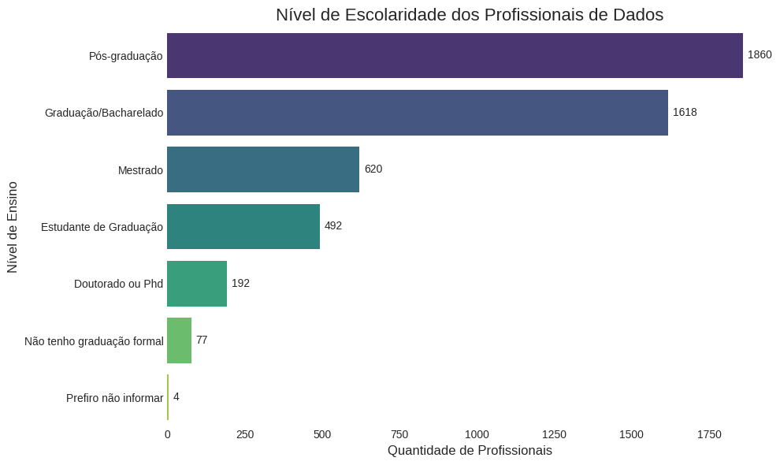

```python
# --- Análise: Nível de Escolaridade ---

# Contagem de valores para a coluna de nível de ensino
nivel_counts = df_subset['1.l_nivel_de_ensino'].value_counts().reset_index()
nivel_counts.columns = ['Nível de Ensino', 'Quantidade']

# Exibindo a tabela com os resultados
print("--- Distribuição por Nível de Escolaridade ---")
print(nivel_counts.to_string(index=False))

# Gráfico de Barras Horizontais com Seaborn
plt.figure(figsize=(10, 6))
ax = sns.barplot(
    data=nivel_counts,
    x='Quantidade',
    y='Nível de Ensino',
    palette='viridis'
)

# Adicionar os valores nas barras
for p in ax.patches:
    width = p.get_width()
    ax.text(width + 15,  # Posição x do texto (um pouco à frente da barra)
            p.get_y() + p.get_height() / 2, # Posição y do texto (no meio da barra)
            f'{int(width)}', # O texto a ser exibido
            va='center', # Alinhamento vertical
            ha='left')   # Alinhamento horizontal

plt.title('Nível de Escolaridade dos Profissionais de Dados', fontsize=16)
plt.xlabel('Quantidade de Profissionais', fontsize=12)
plt.ylabel('Nível de Ensino', fontsize=12)
plt.grid(axis='x', linestyle='--', alpha=0.6)
plt.box(False) # Remove a "caixa" ao redor do gráfico
plt.tight_layout()
plt.show()
```

## Análise da Área de Formação

### Origens Acadêmicas: Uma Área Multidisciplinar

A análise das áreas de formação dos profissionais de dados mostra que o campo é **multidisciplinar**. Embora haja uma forte concentração de talentos vindo de cursos de tecnologia, o setor atrai especialistas de diversas áreas do conhecimento.

- **Domínio da Tecnologia e Exatas**: A área de **Computação e afins (1.930)** é a principal fonte de talentos. Em seguida, vêm as **Outras Engenharias (1.019)** e as carreiras de **Estatística e Matemática (439)**. Juntos, esses grupos formam a base tecnológica e quantitativa do setor.
- **Relevância do Conhecimento de Negócio**: Um ponto importante é a forte presença de profissionais de **Economia, Administração e áreas correlatas (735)**. Isso mostra que a capacidade de usar a análise de dados para resolver problemas de negócio é bastante valorizada.
- **Diversidade de Backgrounds**: Profissionais de áreas como **Marketing e Comunicação (170)**, **Ciências Biológicas e da Saúde (117)** e até **Química/Física (112)** ilustram a versatilidade da ciência de dados. A habilidade de analisar dados é uma competência que agrega valor em praticamente qualquer setor.

### Interpretação e Implicações

A diversidade de formações enriquece o mercado de dados, trazendo diferentes perspectivas para a resolução de problemas. Enquanto a base técnica é essencial, a capacidade de entender o contexto (seja ele financeiro, mercadológico ou científico) é o que transforma dados em decisões estratégicas.

Essa pluralidade sugere que as oportunidades na área de dados não estão limitadas a um único perfil. Profissionais que combinam seu conhecimento de área específica com habilidades analíticas têm um grande potencial para se destacar e causar impacto.

```
--- Top 10 Áreas de Formação ---
                                                      Área de Formação  Quantidade
      Computação / Engenharia de Software / Sistemas de Informação/ TI        1930
         Outras Engenharias (não incluir engenharia de software ou TI)        1019
          Economia/ Administração / Contabilidade / Finanças/ Negócios         735
Estatística/ Matemática / Matemática Computacional/ Ciências Atuariais         439
                                                           Outra opção         260
 Marketing / Publicidade / Comunicação / Jornalismo / Ciências Sociais         170
                Ciências Biológicas/ Farmácia/ Medicina/ Área da Saúde         117
                                                      Química / Física         112
                                                         Não informado          81
```

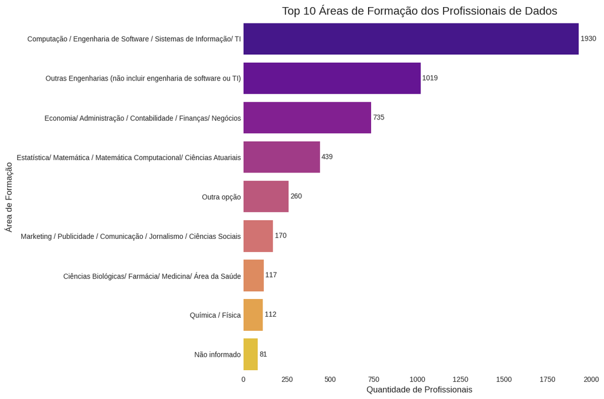

```python
# --- Análise: Área de Formação ---

# Contagem de valores e seleção do Top 10
area_counts = df_subset['1.m_área_de_formação'].value_counts().reset_index()
area_counts.columns = ['Área de Formação', 'Quantidade']
top_10_areas = area_counts.head(10)

# Exibindo a tabela com o Top 10
print("\n--- Top 10 Áreas de Formação ---")
print(top_10_areas.to_string(index=False))

# Gráfico de Barras Horizontais para o Top 10
plt.figure(figsize=(12, 8))
ax = sns.barplot(
    data=top_10_areas,
    x='Quantidade',
    y='Área de Formação',
    palette='plasma'
)

# Adicionar os valores nas barras
for p in ax.patches:
    width = p.get_width()
    ax.text(width + 10,  # Posição x
            p.get_y() + p.get_height() / 2, # Posição y
            f'{int(width)}', # Texto
            va='center',
            ha='left')

plt.title('Top 10 Áreas de Formação dos Profissionais de Dados', fontsize=16)
plt.xlabel('Quantidade de Profissionais', fontsize=12)
plt.ylabel('Área de Formação', fontsize=12)
plt.grid(axis='x', linestyle='--', alpha=0.6)
plt.box(False)
plt.tight_layout()
plt.show()
```

## Análise de Experiência por Nível de Senioridade

A análise do tempo de experiência na área de dados revela uma progressão de carreira clara e um padrão inesperado sobre a origem dos profissionais.

### A Escalada na Carreira de Dados

Os dados mostram uma escada de carreira consistente e bem definida, com o acúmulo de experiência prática como principal fator.

### Interpretação e Implicações

A combinação dessas análises nos permite tirar duas conclusões principais:

1. **Carreira Estruturada**: O caminho de Júnior para Sênior na área de dados é claro e leva, em média, de 5 a 6 anos de experiência dedicada. Isso demonstra a maturidade do mercado.
2. **O Fenômeno da Migração Direta**: Os números baixos de experiência prévia em TI sugerem que uma grande parte dos profissionais não está migrando de outras carreiras de tecnologia (como desenvolvimento de software), mas sim **iniciando sua jornada profissional diretamente na área de dados**. Isso indica que "Dados" se estabeleceu como um ponto de partida para muitas carreiras, impulsionado por formações e cursos específicos na área.

Em resumo, o mercado de dados brasileiro possui uma trilha de crescimento bem definida e, ao mesmo tempo, se consolida como um campo autônomo que atrai novos talentos "nativos de dados".

```
--- Estatísticas: Tempo de Experiência em DADOS por Nível ---
                   count      mean       std  min  25%  50%  75%   max
2.g_nivel
Júnior             868.0  1.402074  1.296422  0.0  0.5  1.5  1.5  11.0
Pleno             1377.0  3.210966  1.990615  0.0  1.5  3.5  3.5  11.0
Sênior            1573.0  5.901780  3.041651  0.0  3.5  5.5  8.5  11.0
Liderança/Gestão     0.0       NaN       NaN  NaN  NaN  NaN  NaN   NaN
```

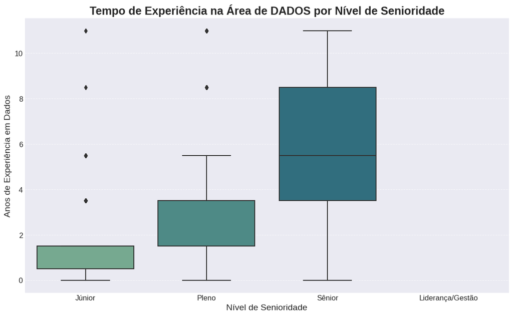

```
--- Estatísticas: Tempo de Experiência em TI (Geral) por Nível ---
                   count      mean       std  min  25%  50%  75%   max
2.g_nivel
Júnior             868.0  0.734447  1.643568  0.0  0.0  0.0  0.5  11.0
Pleno             1377.0  1.182643  2.391515  0.0  0.0  0.0  1.5  11.0
Sênior            1573.0  2.748570  3.886454  0.0  0.0  0.5  3.5  11.0
Liderança/Gestão     0.0       NaN       NaN  NaN  NaN  NaN  NaN   NaN
```

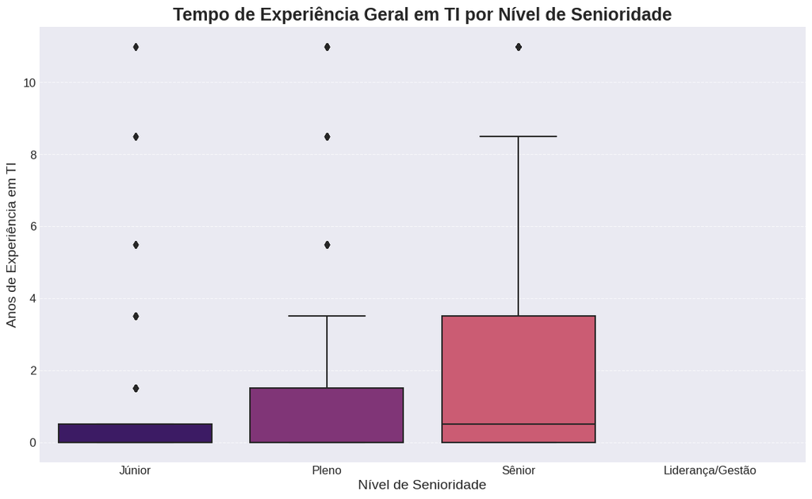

```python
# --- Preparação dos Dados para Análise de Experiência ---

# Filtrar o DataFrame para incluir apenas profissionais empregados que informaram o nível
df_exp = df_subset[~df_subset['2.g_nivel'].isin(['Não aplicável', 'Não informado'])].copy()

# Definir a ordem lógica dos níveis de senioridade
ordem_niveis = ['Júnior', 'Pleno', 'Sênior', 'Liderança/Gestão']

# Aplicar a ordem como uma categoria no DataFrame
df_exp['2.g_nivel'] = pd.Categorical(df_exp['2.g_nivel'], categories=ordem_niveis, ordered=True)

# Remover quaisquer linhas onde a ordem não pôde ser aplicada (NaNs) e onde a experiência é nula
df_exp.dropna(subset=['2.g_nivel', '2.i_tempo_de_experiencia_em_dados_num', '2.j_tempo_de_experiencia_em_ti_num'], inplace=True)


# --- Análise 1: Tempo de Experiência na ÁREA DE DADOS por Nível ---

# Gerar dados descritivos (mediana, média, etc.)
exp_dados_stats = df_exp.groupby('2.g_nivel')['2.i_tempo_de_experiencia_em_dados_num'].describe()

print("--- Estatísticas: Tempo de Experiência em DADOS por Nível ---")
print(exp_dados_stats)

# Gráfico de Boxplot para Experiência em DADOS
plt.figure(figsize=(14, 8))
sns.boxplot(
    data=df_exp,
    x='2.g_nivel',
    y='2.i_tempo_de_experiencia_em_dados_num',
    order=ordem_niveis,
    palette='crest'
)

plt.title('Tempo de Experiência na Área de DADOS por Nível de Senioridade', fontsize=18, fontweight='bold')
plt.xlabel('Nível de Senioridade', fontsize=14)
plt.ylabel('Anos de Experiência em Dados', fontsize=14)
plt.xticks(fontsize=12)
plt.yticks(fontsize=12)
plt.grid(axis='y', linestyle='--', alpha=0.7)
plt.show()


# --- Análise 2: Tempo de Experiência em TI (GERAL) por Nível ---

# Gerar dados descritivos
exp_ti_stats = df_exp.groupby('2.g_nivel')['2.j_tempo_de_experiencia_em_ti_num'].describe()

print("\n\n--- Estatísticas: Tempo de Experiência em TI (Geral) por Nível ---")
print(exp_ti_stats)

# Gráfico de Boxplot para Experiência em TI
plt.figure(figsize=(14, 8))
sns.boxplot(
    data=df_exp,
    x='2.g_nivel',
    y='2.j_tempo_de_experiencia_em_ti_num',
    order=ordem_niveis,
    palette='magma'
)

plt.title('Tempo de Experiência Geral em TI por Nível de Senioridade', fontsize=18, fontweight='bold')
plt.xlabel('Nível de Senioridade', fontsize=14)
plt.ylabel('Anos de Experiência em TI', fontsize=14)
plt.xticks(fontsize=12)
plt.yticks(fontsize=12)
plt.grid(axis='y', linestyle='--', alpha=0.7)
plt.show()
```

## Análise Salarial por Região no Brasil

A análise da remuneração dos profissionais de dados revela uma clara **disparidade salarial** entre as regiões do país, com o Sudeste se consolidando como o polo de maior valorização financeira.

### Discrepâncias Regionais na Remuneração

A localização geográfica é um fator determinante para o potencial salarial de um profissional de dados.

### Interpretação e Implicações

A diferença salarial entre o Sudeste e as demais regiões, especialmente o Norte, pode ultrapassar os 30% na média. Essa disparidade pode ser um fator decisivo na movimentação de talentos, com profissionais se mudando em busca de melhores oportunidades financeiras.

No entanto, com a consolidação do **trabalho remoto**, essa diferença pode começar a diminuir. Empresas do Sudeste podem contratar talentos de outras regiões, e profissionais do Norte e Nordeste podem ter acesso a salários mais altos sem a necessidade de se mudar. Para as empresas, entender essas diferenças é crucial para definir estratégias de contratação e retenção de talentos em um mercado cada vez mais competitivo e nacionalizado.

```
--- Estatísticas: Faixa Salarial (R$) por Região ---
                         count      mean      std    min     25%      50%  \
1.i.2_regiao_onde_mora
Centro-oeste             300.0  10165.49  7899.27  500.0  5000.5   7000.5
Nordeste                 447.0   9671.64  7930.40  500.0  5000.5   7000.5
Norte                     57.0   8711.02  6803.99  500.0  3500.5   7000.5
Sudeste                 2940.0  12620.75  8816.51  500.0  7000.5  10000.5
Sul                      989.0  10394.84  7285.71  500.0  5000.5  10000.5

                            75%      max
1.i.2_regiao_onde_mora
Centro-oeste            14000.5  35000.5
Nordeste                14000.5  41001.0
Norte                   10000.5  35000.5
Sudeste                 18000.5  41001.0
Sul                     14000.5  41001.0
```

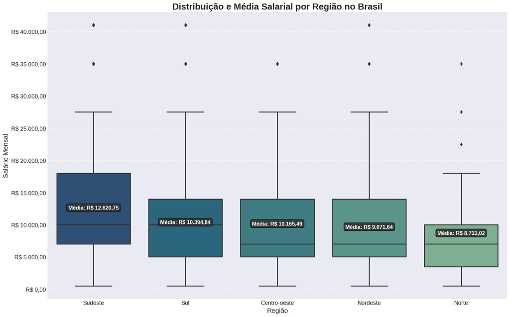

```python
from matplotlib.ticker import FuncFormatter

# --- Preparação dos Dados ---

# Filtra o DataFrame, focando apenas em salário e região
df_salario_regiao = df_subset[
    ~df_subset['2.h_faixa_salarial'].isin(['Não aplicável', 'Não informado']) &
    ~df_subset['1.i.2_regiao_onde_mora'].isin(['Não informado'])
].copy()

# --- Verificação de Segurança ---
if df_salario_regiao.empty:
    print("ALERTA: O DataFrame está vazio após a filtragem.")
    print("Nenhum gráfico será gerado.")
else:
    # --- Geração dos Dados em Texto ---

    # Gerar estatísticas descritivas do salário por região
    salario_regiao_stats = df_salario_regiao.groupby('1.i.2_regiao_onde_mora')['2.h_faixa_salarial_num'].describe()

    print("--- Estatísticas: Faixa Salarial (R$) por Região ---")
    print(salario_regiao_stats.round(2)) # Arredondando para 2 casas decimais


    # --- Geração do Gráfico Aprimorado ---

    # Função para formatar números como moeda brasileira (R$)
    def formatar_reais(valor, pos):
        # A formatação padrão usa vírgula para milhar. Trocamos para o padrão brasileiro.
        s = f'R$ {valor:,.2f}'.replace(',', 'X').replace('.', ',').replace('X', '.')
        return s

    # Calcular a ordem das regiões com base na mediana salarial (da maior para a menor)
    ordem_regioes_por_salario = salario_regiao_stats.sort_values(by='50%', ascending=False).index

    plt.figure(figsize=(16, 10))
    ax = sns.boxplot(
        data=df_salario_regiao,
        x='1.i.2_regiao_onde_mora',
        y='2.h_faixa_salarial_num',
        order=ordem_regioes_por_salario,
        palette='crest_r', # Usando uma paleta reversa para um visual diferente
        linewidth=2
    )

    # --- ADICIONAR OS RÓTULOS DE MÉDIA SALARIAL ---
    # Iterar sobre cada região na ordem do gráfico
    for i, regiao in enumerate(ordem_regioes_por_salario):
        # Obter a média salarial da tabela de estatísticas
        media_salarial = salario_regiao_stats.loc[regiao, 'mean']

        # Formatar o texto do rótulo
        texto_media = formatar_reais(media_salarial, None)

        # Adicionar o texto no gráfico
        ax.text(
            x=i,  # Posição no eixo X (0 para a primeira região, 1 para a segunda, etc.)
            y=media_salarial, # Posição no eixo Y, alinhada com a média
            s=f'Média: {texto_media}', # O texto a ser exibido
            ha='center', # Alinhamento horizontal centralizado
            va='center', # Alinhamento vertical centralizado
            fontsize=12,
            fontweight='bold',
            color='white',
            bbox=dict(facecolor='#333333', alpha=0.9, boxstyle='round,pad=0.3') # Caixa de fundo para legibilidade
        )

    # --- Melhorando a estética geral do gráfico ---
    plt.title('Distribuição e Média Salarial por Região no Brasil', fontsize=20, fontweight='bold')
    plt.xlabel('Região', fontsize=15)
    plt.ylabel('Salário Mensal', fontsize=15)
    plt.xticks(fontsize=13)
    plt.yticks(fontsize=13)
    plt.grid(axis='y', linestyle='--', alpha=0.7)

    # Aplicar a formatação de moeda ao eixo Y
    ax.yaxis.set_major_formatter(FuncFormatter(formatar_reais))

    sns.despine()
    plt.tight_layout()
    plt.show()
```

# Insights e Recomendações

A análise exploratória do dataset **"State of Data Brazil 2024–2025"** nos oferece uma fotografia detalhada do mercado de dados no país, revelando tendências claras, desafios estruturais e oportunidades estratégicas. A seguir, apresentamos um sumário dos principais achados e recomendações direcionadas para empresas, profissionais e a comunidade em geral.

## 📌 Sumário dos Achados Mais Importantes

### 📍 Concentração Geográfica e Salarial

O mercado de dados brasileiro é fortemente concentrado na **Região Sudeste**, que não apenas reúne a maioria dos profissionais, mas também oferece a **maior média salarial** (R$ 12.620,75). As regiões Sul e Centro-Oeste seguem com remunerações competitivas, enquanto Norte e Nordeste apresentam salários mais baixos, evidenciando uma **forte disparidade regional**.

### 👤 Perfil Demográfico

A área de dados é majoritariamente composta por profissionais:

- Jovens (idade média de **32 anos**)
- Brancos (**67,5%**)
- Do sexo masculino (**76,1%**)

Esses números contrastam com a demografia nacional, onde:

- A população negra (preta e parda) é majoritária
- As mulheres representam mais de **51%** da população

➡️ **Conclusão:** Existem *gaps críticos* de diversidade de gênero e raça.

### 🎓 Qualificação Elevada e Multidisciplinar

- A maioria dos profissionais possui **pós-graduação (1.860)** ou **graduação (1.618)**
- Predominância da área de **Computação**
- Forte presença de **Engenharias, Economia e Administração**

➡️ O campo é claramente **multidisciplinar**.

### 🚀 A Trajetória "Data-First"

- Muitos profissionais estão **iniciando diretamente em dados**, sem vir de outras áreas de TI
- A progressão de carreira, de Júnior a Sênior, leva em média de **5 a 6 anos**

## 🎯 Recomendações Estratégicas

### 1. Ampliar o Recrutamento Geográfico

Empresas (especialmente do Sudeste) devem:

- Criar estratégias para **contratar talentos de outras regiões**
- Reduzir custos e **aumentar a diversidade de perspectivas**

### 2. Investir em Diversidade e Inclusão (D&I)

- Fortalecer programas de **contratação afirmativa**
- Focar em **mulheres** e **pessoas negras**
- ➕ Times diversos são mais **inovadores**

### 3. Valorizar a Multidisciplinaridade

- Reconhecer profissionais com formações variadas (ex: Finanças, Marketing)
- A combinação entre **conhecimento de negócio** e **habilidades analíticas** é um diferencial

### 4. Foco na Especialização Contínua

- O mercado valoriza a qualificação contínua
- Buscar **pós-graduações, mestrados e certificações** eleva a competitividade

### 5. Desenvolver Habilidades de Negócio

- Entender o **contexto do negócio** é essencial para gerar impacto e crescer na carreira

### 6. Explorar Oportunidades Remotas

- Profissionais de regiões com menos vagas devem mirar em **posições remotas** nos grandes centros

### 7. Fomentar Polos Regionais de Tecnologia

- Incentivar a criação de **hubs de tecnologia** fora do eixo Sul-Sudeste
- Papel fundamental de **governos e instituições de ensino**

### 8. Promover a Educação STEM para Minorias

- Criar programas desde a base para atrair **mulheres e pessoas negras** às áreas de:
  - Ciência
  - Tecnologia
  - Engenharia
  - Matemática

### 9. Democratizar o Acesso à Formação em Dados

- Apoiar **rotas alternativas** ao ensino superior tradicional:
  - **Bootcamps**
  - **Cursos técnicos**
- Reduzir a barreira de entrada e **aumentar a diversidade**

## ✅ Conclusão

Este notebook apresentou uma **análise detalhada** do perfil dos profissionais de dados no Brasil, destacando:

- Composição demográfica
- Distribuição geográfica
- Formações acadêmicas
- Trajetórias de carreira

🔍 A área de dados é:

- Dinâmica
- Altamente qualificada
- Em franca expansão

Por outro lado, enfrenta **desafios importantes**:

- Baixa diversidade de gênero e raça
- Forte concentração de oportunidades no Sudeste

📊 A predominância de profissionais jovens e o surgimento da carreira **"data-first"** indicam a força que o mercado já possui.

💡 A **multidisciplinaridade** enriquece o setor, mostrando que a análise de dados é uma competência **universalmente valiosa**.

## 🌎 Considerações Finais

A **democratização do acesso** e a **promoção da diversidade** são não apenas imperativos sociais, mas também **estratégicos** para garantir que o Brasil continue a evoluir como um **player competitivo e inovador** no cenário global de dados.